# Reproducible Research Project 1

Philip Short

April 19, 2016

## Introduction

This was the first project for the **Reproducible Research** course in Coursera’s Data Science specialization track.

### Data

The data for this assignment was downloaded from the course web site:

- Dataset: [Activity monitoring data](https://d396qusza40orc.cloudfront.net/repdata%2Fdata%2Factivity.zip) [52K]

The variables included in this dataset are:

- **steps**: Number of steps taking in a 5-minute interval (missing values are coded as `NA`)
- **date**: The date on which the measurement was taken in YYYY-MM-DD format
- **interval**: Identifier for the 5-minute interval in which measurement was taken

The dataset is stored in a comma-separated-value (CSV) file and there are a total of 17,568 observations in this dataset.

## Loading and preprocessing the data

### loading libraries to be used with data.

```r
library(knitr)
library(dplyr)
library(lubridate)
```

```r
library(ggplot2)
```

### Loading in CSV file from current directory

```r
data <- read.csv("activity.csv", header = TRUE, sep = ',', colClasses = c("numeric", "character", "integer"))
```

### cleaning up and checking the activity.csv data.

```r
data$date <-ymd(data$date)

str(data)
```

```
## 'data.frame':    17568 obs. of  3 variables:
##  $ steps   : num  NA NA NA NA NA NA NA NA NA NA ...
##  $ date    : Date, format: "2012-10-01" "2012-10-01" ...
##  $ interval: int  0 5 10 15 20 25 30 35 40 45 ...
```

```r
head(data)
```

```
##   steps       date interval
## 1    NA 2012-10-01        0
## 2    NA 2012-10-01        5
## 3    NA 2012-10-01       10
## 4    NA 2012-10-01       15
## 5    NA 2012-10-01       20
## 6    NA 2012-10-01       25
```

## What is mean total number of steps taken per day?

```r
steps <- data %>%
  filter(!is.na(steps)) %>%
  group_by(date) %>%
  summarize(steps = sum(steps))


mean_steps <- mean(steps$steps, na.rm = TRUE)
median_steps <- median(steps$steps, na.rm = TRUE)

p <-ggplot(steps, aes(x = steps)) +geom_histogram(fill = "blue", binwidth = 1000)+labs(title = "Histogram of Steps Per Day", x = "Steps Per Day", y = "Frequency")
```

Add lines for mean and median on plot

```r
p <-p + geom_vline(xintercept = median_steps, color ="red") +geom_vline(xintercept = mean_steps, color="green", linetype = "longdash")
```

Add text to tell mean and meadian values on plot

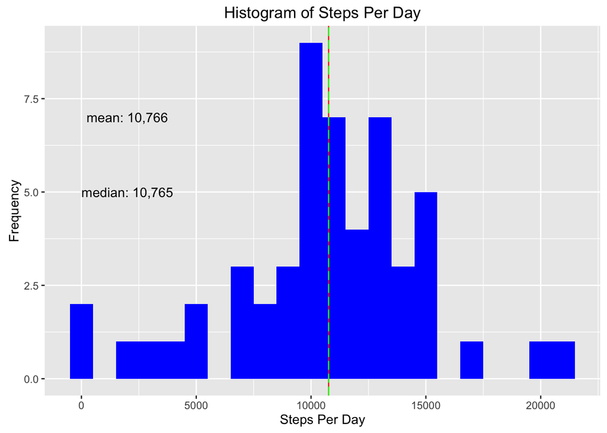

```r
p + annotate("text", x = 2000, y = 7, label = "mean: 10,766") + annotate("text", x= 2000, y=5, label="median: 10,765")
```

```r
mean_steps
```

```
## [1] 10766.19
```

```r
median_steps
```

```
## [1] 10765
```

## What is the average daily activity pattern?

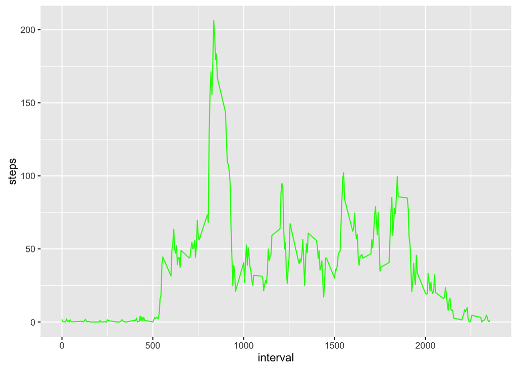

```r
interval <- data %>%filter(!is.na(steps)) %>%group_by(interval) %>%summarize(steps = mean(steps))
ggplot(interval, aes(x=interval, y=steps)) + geom_line(color = "green")
```

```r
a <- interval[which.max(interval$steps),]
Steps_High <-a$steps
Interval_High <-a$interval

Interval_High
```

```
## [1] 835
```

```r
Steps_High
```

```
## [1] 206.1698
```

## Imputing missing values

Checking for number of ’NA’s in the data

```r
sum(is.na(data$steps))
```

```
## [1] 2304
```

Now cleaning the data

```r
data_full <- data
nas <- is.na(data_full$steps)
avg_interval <- tapply(data_full$steps, data_full$interval, mean, na.rm=TRUE, simplify=TRUE)
data_full$steps[nas] <- avg_interval[as.character(data_full$interval[nas])]
```

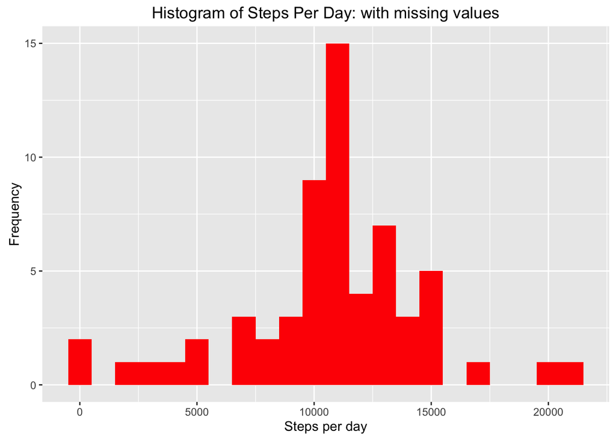

```r
steps_full <- data_full %>%
  filter(!is.na(steps)) %>%
  group_by(date) %>%
  summarize(steps = sum(steps))

ggplot(steps_full, aes(x = steps)) +
  geom_histogram(fill = "red", binwidth = 1000) +
  labs(title = "Histogram of Steps Per Day: with missing values", x = "Steps per day", y = "Frequency")
```

```r
mean_steps_full <- mean(steps_full$steps, na.rm = TRUE)
median_steps_full <- median(steps_full$steps, na.rm = TRUE)

mean_steps_full
```

```
## [1] 10766.19
```

```r
median_steps_full
```

```
## [1] 10766.19
```

## Are there differences in activity patterns between weekdays and weekends?

Pulliung out data that was collected on the weekend, using weekdays() and mutate() to add a new coloumn to the data.

```r
data_full <- mutate(data_full, weektype = ifelse(weekdays(data_full$date) == "Saturday" | weekdays(data_full$date) == "Sunday", "weekend", "weekday"))
data_full$weektype <- as.factor(data_full$weektype)
```

```r
interval_full <- data_full %>%
  group_by(interval, weektype) %>%
  summarise(steps = mean(steps))
```

Plotting of weekday vs weekend

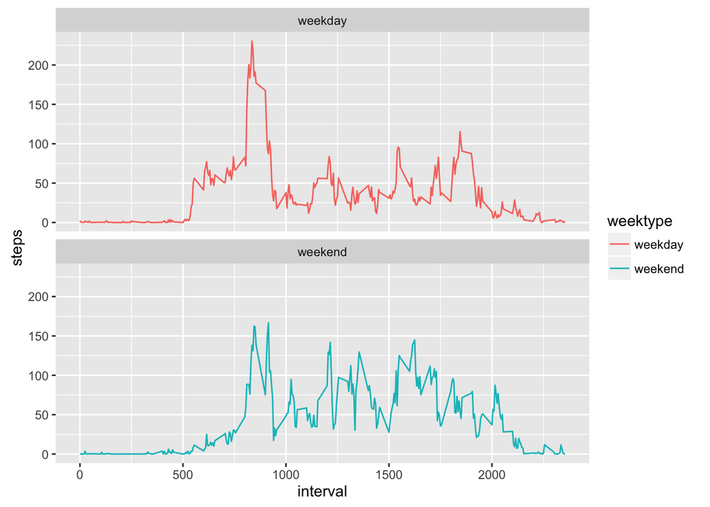

```r
 ggplot(interval_full, aes(x=interval, y=steps, color = weektype)) +
  geom_line() +
  facet_wrap(~weektype, ncol = 1, nrow=2)
```

The avgerage number of steps is higher on the weekend, which makes sense that the user is probably sitting at work or school more during the weekday.